# 1

**Data Selection**: Explain why this data was selected. What are the overall characteristics of the data.

```r
d <- read.csv("insurance.csv")
d
```

| age | sex | bmi | children | smoker | region | charges |
| --- | --- | --- | --- | --- | --- | --- |
| 19 | female | 27.900 | 0 | yes | southwest | 16884.924 |
| 18 | male | 33.770 | 1 | no | southeast | 1725.552 |
| 28 | male | 33.000 | 3 | no | southeast | 4449.462 |
| 33 | male | 22.705 | 0 | no | northwest | 21984.471 |
| 32 | male | 28.880 | 0 | no | northwest | 3866.855 |
| 31 | female | 25.740 | 0 | no | southeast | 3756.622 |
| 46 | female | 33.440 | 1 | no | southeast | 8240.590 |
| 37 | female | 27.740 | 3 | no | northwest | 7281.506 |
| 37 | male | 29.830 | 2 | no | northeast | 6406.411 |
| 60 | female | 25.840 | 0 | no | northwest | 28923.137 |
| 25 | male | 26.220 | 0 | no | northeast | 2721.321 |
| 62 | female | 26.290 | 0 | yes | southeast | 27808.725 |
| 23 | male | 34.400 | 0 | no | southwest | 1826.843 |
| 56 | female | 39.820 | 0 | no | southeast | 11090.718 |
| 27 | male | 42.130 | 0 | yes | southeast | 39611.758 |
| 19 | male | 24.600 | 1 | no | southwest | 1837.237 |
| 52 | female | 30.780 | 1 | no | northeast | 10797.336 |
| 23 | male | 23.845 | 0 | no | northeast | 2395.172 |
| 56 | male | 40.300 | 0 | no | southwest | 10602.385 |
| 30 | male | 35.300 | 0 | yes | southwest | 36837.467 |
| 60 | female | 36.005 | 0 | no | northeast | 13228.847 |
| 30 | female | 32.400 | 1 | no | southwest | 4149.736 |
| 18 | male | 34.100 | 0 | no | southeast | 1137.011 |
| 34 | female | 31.920 | 1 | yes | northeast | 37701.877 |
| 37 | male | 28.025 | 2 | no | northwest | 6203.902 |
| 59 | female | 27.720 | 3 | no | southeast | 14001.134 |
| 63 | female | 23.085 | 0 | no | northeast | 14451.835 |
| 55 | female | 32.775 | 2 | no | northwest | 12268.632 |
| 23 | male | 17.385 | 1 | no | northwest | 2775.192 |
| 31 | male | 36.300 | 2 | yes | southwest | 38711.000 |
| ⋮ | ⋮ | ⋮ | ⋮ | ⋮ | ⋮ | ⋮ |
| 25 | female | 30.200 | 0 | yes | southwest | 33900.653 |
| 41 | male | 32.200 | 2 | no | southwest | 6875.961 |
| 42 | male | 26.315 | 1 | no | northwest | 6940.910 |
| 33 | female | 26.695 | 0 | no | northwest | 4571.413 |
| 34 | male | 42.900 | 1 | no | southwest | 4536.259 |
| 19 | female | 34.700 | 2 | yes | southwest | 36397.576 |
| 30 | female | 23.655 | 3 | yes | northwest | 18765.875 |
| 18 | male | 28.310 | 1 | no | northeast | 11272.331 |
| 19 | female | 20.600 | 0 | no | southwest | 1731.677 |
| 18 | male | 53.130 | 0 | no | southeast | 1163.463 |
| 35 | male | 39.710 | 4 | no | northeast | 19496.719 |
| 39 | female | 26.315 | 2 | no | northwest | 7201.701 |
| 31 | male | 31.065 | 3 | no | northwest | 5425.023 |
| 62 | male | 26.695 | 0 | yes | northeast | 28101.333 |
| 62 | male | 38.830 | 0 | no | southeast | 12981.346 |
| 42 | female | 40.370 | 2 | yes | southeast | 43896.376 |
| 31 | male | 25.935 | 1 | no | northwest | 4239.893 |
| 61 | male | 33.535 | 0 | no | northeast | 13143.337 |
| 42 | female | 32.870 | 0 | no | northeast | 7050.021 |
| 51 | male | 30.030 | 1 | no | southeast | 9377.905 |
| 23 | female | 24.225 | 2 | no | northeast | 22395.744 |
| 52 | male | 38.600 | 2 | no | southwest | 10325.206 |
| 57 | female | 25.740 | 2 | no | southeast | 12629.166 |
| 23 | female | 33.400 | 0 | no | southwest | 10795.937 |
| 52 | female | 44.700 | 3 | no | southwest | 11411.685 |
| 50 | male | 30.970 | 3 | no | northwest | 10600.548 |
| 18 | female | 31.920 | 0 | no | northeast | 2205.981 |
| 18 | female | 36.850 | 0 | no | southeast | 1629.833 |
| 21 | female | 25.800 | 0 | no | southwest | 2007.945 |
| 61 | female | 29.070 | 0 | yes | northwest | 29141.360 |

### My answer:

This dataset was selected because it relates to medical expenses, which is a good indication of health condition. There are factors that are the potential factors may effect our health condition, which can be explained by how much people spend on their medical expense.  
The overall dataset was composed of different individual's personal information including age, gender, bmi, having children or not and the area they live in.

# 2

**Stakeholder**: Describe your stakeholder. Who is the potential sponsor of your project? For example: a real estate investor, the police department, a city mayor, etc.

### My answer:

The stakeholders and potential sponsor of my project are the insurance companies.

# 3

**Objective**: Project objective, justification, expected outcome. How your results may impact your stake holders. Which decisions or changes will the stakeholder be able to make based on this project

### My answer:

- Project objective: to find correlation between different factors with annual medical expense
- Justification: Which one of the factor has the strongest correlation with medical expenses
- The expected outcome would be people in bad habit or health condition tend to spend more on medical expenses
- My stakeholder could adjust the price setting according to the result of this project to maximize the profit

# 4

**Background Research**: List here all other studies related to linear regression published with the same dataset, and how your proposed study is different from them. If no other linear regression studies were conducted with the same dataset, you should specify: "No other studies available"

### My answer:

- There is one research on this dataset I found with linear regression, it illustrated the overall correlation between all factos and the medical expense without remove any factors out. For mine, I am going to remove some not so relavant factors out of the model.
- Also the author found correlation of bmi with expenses. However, he didn't subset the smokers with nonsomkers even those two groups have different linear regression model. Mine would be covering that part to go more detail by subsetting.

# 5

Create some exploratory analysis on your data using core R functions and visualizations. Cluster the information into different groups to explore the possibilities for your proposed project. Summarize your data and conduct some statistics. Explain your findings in English.  
**Data Summary**: Show summary information of the different variables. Select the columns you are interested in. Explain each column, its range and purpose

```r
summary(d)
```

```
      age            sex           bmi           children     smoker
 Min.   :18.00   female:662   Min.   :15.96   Min.   :0.000   no :1064
 1st Qu.:27.00   male  :676   1st Qu.:26.30   1st Qu.:0.000   yes: 274
 Median :39.00                Median :30.40   Median :1.000
 Mean   :39.21                Mean   :30.66   Mean   :1.095
 3rd Qu.:51.00                3rd Qu.:34.69   3rd Qu.:2.000
 Max.   :64.00                Max.   :53.13   Max.   :5.000
       region       charges
 northeast:324   Min.   : 1122
 northwest:325   1st Qu.: 4740
 southeast:364   Median : 9382
 southwest:325   Mean   :13270
                 3rd Qu.:16640
                 Max.   :63770
```

### My answer

# 6

**Data Cleaning**: Clean the data, removing rows and columns that have no useful information or no information at all

```r
anyNA(d)
```

FALSE

### My answer

After glancing over the summary, there is no obvious error shown. Then double check the data frame using anyNA function and concludes all information is valid and useful.

# 7

**Adaptation**: Create at least two additional columns that are necessary for your study. They can be calculated columns or aggregated columns.

### My answer

Since there is a range of normal BMI, I am creating a new column taht seperates normal and not normal BMI value.

```r
d$Normal_BMI[d$bmi >= 18.500 & d$bmi <= 24.900] <- TRUE
d$Normal_BMI[d$bmi < 18.500 | d$bmi > 24.900] <- FALSE
d
```

| age | sex | bmi | children | smoker | region | charges | Normal_BMI |
| --- | --- | --- | --- | --- | --- | --- | --- |
| 19 | female | 27.900 | 0 | yes | southwest | 16884.924 | FALSE |
| 18 | male | 33.770 | 1 | no | southeast | 1725.552 | FALSE |
| 28 | male | 33.000 | 3 | no | southeast | 4449.462 | FALSE |
| 33 | male | 22.705 | 0 | no | northwest | 21984.471 | TRUE |
| 32 | male | 28.880 | 0 | no | northwest | 3866.855 | FALSE |
| 31 | female | 25.740 | 0 | no | southeast | 3756.622 | FALSE |
| 46 | female | 33.440 | 1 | no | southeast | 8240.590 | FALSE |
| 37 | female | 27.740 | 3 | no | northwest | 7281.506 | FALSE |
| 37 | male | 29.830 | 2 | no | northeast | 6406.411 | FALSE |
| 60 | female | 25.840 | 0 | no | northwest | 28923.137 | FALSE |
| 25 | male | 26.220 | 0 | no | northeast | 2721.321 | FALSE |
| 62 | female | 26.290 | 0 | yes | southeast | 27808.725 | FALSE |
| 23 | male | 34.400 | 0 | no | southwest | 1826.843 | FALSE |
| 56 | female | 39.820 | 0 | no | southeast | 11090.718 | FALSE |
| 27 | male | 42.130 | 0 | yes | southeast | 39611.758 | FALSE |
| 19 | male | 24.600 | 1 | no | southwest | 1837.237 | TRUE |
| 52 | female | 30.780 | 1 | no | northeast | 10797.336 | FALSE |
| 23 | male | 23.845 | 0 | no | northeast | 2395.172 | TRUE |
| 56 | male | 40.300 | 0 | no | southwest | 10602.385 | FALSE |
| 30 | male | 35.300 | 0 | yes | southwest | 36837.467 | FALSE |
| 60 | female | 36.005 | 0 | no | northeast | 13228.847 | FALSE |
| 30 | female | 32.400 | 1 | no | southwest | 4149.736 | FALSE |
| 18 | male | 34.100 | 0 | no | southeast | 1137.011 | FALSE |
| 34 | female | 31.920 | 1 | yes | northeast | 37701.877 | FALSE |
| 37 | male | 28.025 | 2 | no | northwest | 6203.902 | FALSE |
| 59 | female | 27.720 | 3 | no | southeast | 14001.134 | FALSE |
| 63 | female | 23.085 | 0 | no | northeast | 14451.835 | TRUE |
| 55 | female | 32.775 | 2 | no | northwest | 12268.632 | FALSE |
| 23 | male | 17.385 | 1 | no | northwest | 2775.192 | FALSE |
| 31 | male | 36.300 | 2 | yes | southwest | 38711.000 | FALSE |
| ⋮ | ⋮ | ⋮ | ⋮ | ⋮ | ⋮ | ⋮ | ⋮ |
| 25 | female | 30.200 | 0 | yes | southwest | 33900.653 | FALSE |
| 41 | male | 32.200 | 2 | no | southwest | 6875.961 | FALSE |
| 42 | male | 26.315 | 1 | no | northwest | 6940.910 | FALSE |
| 33 | female | 26.695 | 0 | no | northwest | 4571.413 | FALSE |
| 34 | male | 42.900 | 1 | no | southwest | 4536.259 | FALSE |
| 19 | female | 34.700 | 2 | yes | southwest | 36397.576 | FALSE |
| 30 | female | 23.655 | 3 | yes | northwest | 18765.875 | TRUE |
| 18 | male | 28.310 | 1 | no | northeast | 11272.331 | FALSE |
| 19 | female | 20.600 | 0 | no | southwest | 1731.677 | TRUE |
| 18 | male | 53.130 | 0 | no | southeast | 1163.463 | FALSE |
| 35 | male | 39.710 | 4 | no | northeast | 19496.719 | FALSE |
| 39 | female | 26.315 | 2 | no | northwest | 7201.701 | FALSE |
| 31 | male | 31.065 | 3 | no | northwest | 5425.023 | FALSE |
| 62 | male | 26.695 | 0 | yes | northeast | 28101.333 | FALSE |
| 62 | male | 38.830 | 0 | no | southeast | 12981.346 | FALSE |
| 42 | female | 40.370 | 2 | yes | southeast | 43896.376 | FALSE |
| 31 | male | 25.935 | 1 | no | northwest | 4239.893 | FALSE |
| 61 | male | 33.535 | 0 | no | northeast | 13143.337 | FALSE |
| 42 | female | 32.870 | 0 | no | northeast | 7050.021 | FALSE |
| 51 | male | 30.030 | 1 | no | southeast | 9377.905 | FALSE |
| 23 | female | 24.225 | 2 | no | northeast | 22395.744 | TRUE |
| 52 | male | 38.600 | 2 | no | southwest | 10325.206 | FALSE |
| 57 | female | 25.740 | 2 | no | southeast | 12629.166 | FALSE |
| 23 | female | 33.400 | 0 | no | southwest | 10795.937 | FALSE |
| 52 | female | 44.700 | 3 | no | southwest | 11411.685 | FALSE |
| 50 | male | 30.970 | 3 | no | northwest | 10600.548 | FALSE |
| 18 | female | 31.920 | 0 | no | northeast | 2205.981 | FALSE |
| 18 | female | 36.850 | 0 | no | southeast | 1629.833 | FALSE |
| 21 | female | 25.800 | 0 | no | southwest | 2007.945 | FALSE |
| 61 | female | 29.070 | 0 | yes | northwest | 29141.360 | FALSE |

```r
summary(d)
```

```
      age            sex           bmi           children     smoker
 Min.   :18.00   female:662   Min.   :15.96   Min.   :0.000   no :1064
 1st Qu.:27.00   male  :676   1st Qu.:26.30   1st Qu.:0.000   yes: 274
 Median :39.00                Median :30.40   Median :1.000
 Mean   :39.21                Mean   :30.66   Mean   :1.095
 3rd Qu.:51.00                3rd Qu.:34.69   3rd Qu.:2.000
 Max.   :64.00                Max.   :53.13   Max.   :5.000
       region       charges      Normal_BMI
 northeast:324   Min.   : 1122   Mode :logical
 northwest:325   1st Qu.: 4740   FALSE:1116
 southeast:364   Median : 9382   TRUE :222
 southwest:325   Mean   :13270
                 3rd Qu.:16640
                 Max.   :63770
```

We can see that there are only 222 individual's bmi is within the nornal range.

Then I am adding a second column shows all individuals whose BMI is out of normal range and also smoke (not a pretty healthy life style)

```r
d$Free_Life_Style <- FALSE
d$Free_Life_Style[d$Normal_BMI == FALSE & d$smoker == "yes"] <- TRUE
d
```

| age | sex | bmi | children | smoker | region | charges | Normal_BMI | Free_Life_Style |
| --- | --- | --- | --- | --- | --- | --- | --- | --- |
| 19 | female | 27.900 | 0 | yes | southwest | 16884.924 | FALSE | TRUE |
| 18 | male | 33.770 | 1 | no | southeast | 1725.552 | FALSE | FALSE |
| 28 | male | 33.000 | 3 | no | southeast | 4449.462 | FALSE | FALSE |
| 33 | male | 22.705 | 0 | no | northwest | 21984.471 | TRUE | FALSE |
| 32 | male | 28.880 | 0 | no | northwest | 3866.855 | FALSE | FALSE |
| 31 | female | 25.740 | 0 | no | southeast | 3756.622 | FALSE | FALSE |
| 46 | female | 33.440 | 1 | no | southeast | 8240.590 | FALSE | FALSE |
| 37 | female | 27.740 | 3 | no | northwest | 7281.506 | FALSE | FALSE |
| 37 | male | 29.830 | 2 | no | northeast | 6406.411 | FALSE | FALSE |
| 60 | female | 25.840 | 0 | no | northwest | 28923.137 | FALSE | FALSE |
| 25 | male | 26.220 | 0 | no | northeast | 2721.321 | FALSE | FALSE |
| 62 | female | 26.290 | 0 | yes | southeast | 27808.725 | FALSE | TRUE |
| 23 | male | 34.400 | 0 | no | southwest | 1826.843 | FALSE | FALSE |
| 56 | female | 39.820 | 0 | no | southeast | 11090.718 | FALSE | FALSE |
| 27 | male | 42.130 | 0 | yes | southeast | 39611.758 | FALSE | TRUE |
| 19 | male | 24.600 | 1 | no | southwest | 1837.237 | TRUE | FALSE |
| 52 | female | 30.780 | 1 | no | northeast | 10797.336 | FALSE | FALSE |
| 23 | male | 23.845 | 0 | no | northeast | 2395.172 | TRUE | FALSE |
| 56 | male | 40.300 | 0 | no | southwest | 10602.385 | FALSE | FALSE |
| 30 | male | 35.300 | 0 | yes | southwest | 36837.467 | FALSE | TRUE |
| 60 | female | 36.005 | 0 | no | northeast | 13228.847 | FALSE | FALSE |
| 30 | female | 32.400 | 1 | no | southwest | 4149.736 | FALSE | FALSE |
| 18 | male | 34.100 | 0 | no | southeast | 1137.011 | FALSE | FALSE |
| 34 | female | 31.920 | 1 | yes | northeast | 37701.877 | FALSE | TRUE |
| 37 | male | 28.025 | 2 | no | northwest | 6203.902 | FALSE | FALSE |
| 59 | female | 27.720 | 3 | no | southeast | 14001.134 | FALSE | FALSE |
| 63 | female | 23.085 | 0 | no | northeast | 14451.835 | TRUE | FALSE |
| 55 | female | 32.775 | 2 | no | northwest | 12268.632 | FALSE | FALSE |
| 23 | male | 17.385 | 1 | no | northwest | 2775.192 | FALSE | FALSE |
| 31 | male | 36.300 | 2 | yes | southwest | 38711.000 | FALSE | TRUE |
| ⋮ | ⋮ | ⋮ | ⋮ | ⋮ | ⋮ | ⋮ | ⋮ | ⋮ |
| 25 | female | 30.200 | 0 | yes | southwest | 33900.653 | FALSE | TRUE |
| 41 | male | 32.200 | 2 | no | southwest | 6875.961 | FALSE | FALSE |
| 42 | male | 26.315 | 1 | no | northwest | 6940.910 | FALSE | FALSE |
| 33 | female | 26.695 | 0 | no | northwest | 4571.413 | FALSE | FALSE |
| 34 | male | 42.900 | 1 | no | southwest | 4536.259 | FALSE | FALSE |
| 19 | female | 34.700 | 2 | yes | southwest | 36397.576 | FALSE | TRUE |
| 30 | female | 23.655 | 3 | yes | northwest | 18765.875 | TRUE | FALSE |
| 18 | male | 28.310 | 1 | no | northeast | 11272.331 | FALSE | FALSE |
| 19 | female | 20.600 | 0 | no | southwest | 1731.677 | TRUE | FALSE |
| 18 | male | 53.130 | 0 | no | southeast | 1163.463 | FALSE | FALSE |
| 35 | male | 39.710 | 4 | no | northeast | 19496.719 | FALSE | FALSE |
| 39 | female | 26.315 | 2 | no | northwest | 7201.701 | FALSE | FALSE |
| 31 | male | 31.065 | 3 | no | northwest | 5425.023 | FALSE | FALSE |
| 62 | male | 26.695 | 0 | yes | northeast | 28101.333 | FALSE | TRUE |
| 62 | male | 38.830 | 0 | no | southeast | 12981.346 | FALSE | FALSE |
| 42 | female | 40.370 | 2 | yes | southeast | 43896.376 | FALSE | TRUE |
| 31 | male | 25.935 | 1 | no | northwest | 4239.893 | FALSE | FALSE |
| 61 | male | 33.535 | 0 | no | northeast | 13143.337 | FALSE | FALSE |
| 42 | female | 32.870 | 0 | no | northeast | 7050.021 | FALSE | FALSE |
| 51 | male | 30.030 | 1 | no | southeast | 9377.905 | FALSE | FALSE |
| 23 | female | 24.225 | 2 | no | northeast | 22395.744 | TRUE | FALSE |
| 52 | male | 38.600 | 2 | no | southwest | 10325.206 | FALSE | FALSE |
| 57 | female | 25.740 | 2 | no | southeast | 12629.166 | FALSE | FALSE |
| 23 | female | 33.400 | 0 | no | southwest | 10795.937 | FALSE | FALSE |
| 52 | female | 44.700 | 3 | no | southwest | 11411.685 | FALSE | FALSE |
| 50 | male | 30.970 | 3 | no | northwest | 10600.548 | FALSE | FALSE |
| 18 | female | 31.920 | 0 | no | northeast | 2205.981 | FALSE | FALSE |
| 18 | female | 36.850 | 0 | no | southeast | 1629.833 | FALSE | FALSE |
| 21 | female | 25.800 | 0 | no | southwest | 2007.945 | FALSE | FALSE |
| 61 | female | 29.070 | 0 | yes | northwest | 29141.360 | FALSE | TRUE |

```r
summary(d)
```

```
      age            sex           bmi           children     smoker
 Min.   :18.00   female:662   Min.   :15.96   Min.   :0.000   no :1064
 1st Qu.:27.00   male  :676   1st Qu.:26.30   1st Qu.:0.000   yes: 274
 Median :39.00                Median :30.40   Median :1.000
 Mean   :39.21                Mean   :30.66   Mean   :1.095
 3rd Qu.:51.00                3rd Qu.:34.69   3rd Qu.:2.000
 Max.   :64.00                Max.   :53.13   Max.   :5.000
       region       charges      Normal_BMI      Free_Life_Style
 northeast:324   Min.   : 1122   Mode :logical   Mode :logical
 northwest:325   1st Qu.: 4740   FALSE:1116      FALSE:1114
 southeast:364   Median : 9382   TRUE :222       TRUE :224
 southwest:325   Mean   :13270
                 3rd Qu.:16640
                 Max.   :63770
```

There are 224 individual's life style is not very healthy.

# 8

**Descriptive Analytics**: Create at least 5 different (unique) visualizations that show different aspects of your data related to the research object of your project  
**Outcome**: Explain in words the outcome of your descriptive analysis

```r
install.packages("psych")
library(psych)
```

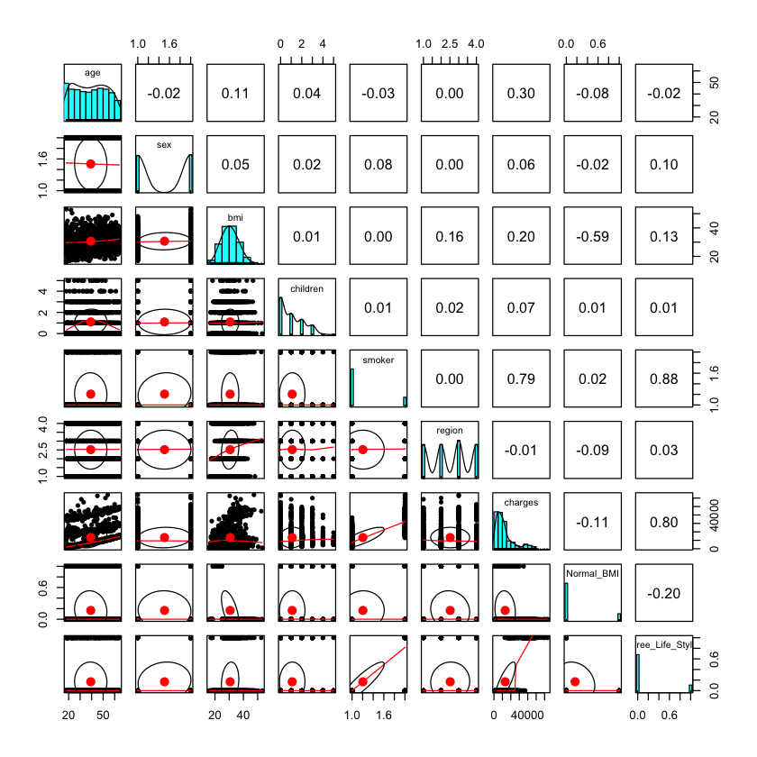

```r
pairs.panels(d)
```

From above we can see that medical expenses are highly correlated to Free_Life_Style, which is the group of people who smoke and also have higher/lower than normal BMI. Medical expenses are also highly correlated with smoker: 79%. But adding BMI higher/lower than normal increases the correlation to 80%.

```r
d$children <- factor(d$children, labels = c(0, 1, 2, 3, 4, 5))
summary(d)
```

```
      age            sex           bmi        children smoker
 Min.   :18.00   female:662   Min.   :15.96   0:574    no :1064
 1st Qu.:27.00   male  :676   1st Qu.:26.30   1:324    yes: 274
 Median :39.00                Median :30.40   2:240
 Mean   :39.21                Mean   :30.66   3:157
 3rd Qu.:51.00                3rd Qu.:34.69   4: 25
 Max.   :64.00                Max.   :53.13   5: 18
       region       charges      Normal_BMI      Free_Life_Style
 northeast:324   Min.   : 1122   Mode :logical   Mode :logical
 northwest:325   1st Qu.: 4740   FALSE:1116      FALSE:1114
 southeast:364   Median : 9382   TRUE :222       TRUE :224
 southwest:325   Mean   :13270
                 3rd Qu.:16640
                 Max.   :63770
```

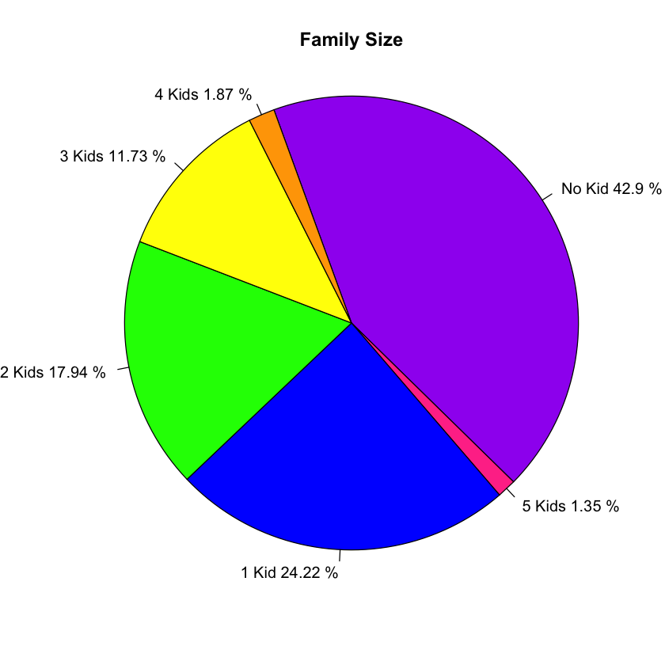

```r
data = c(574, 18, 324, 240, 157, 25)
pct = (data/sum(data))*100
pct = round(pct,2)
labels = c("No Kid", "5 Kids", "1 Kid", "2 Kids", "3 Kids", "4 Kids")
labels = paste(labels, pct, "%")
col = c("purple", "violetred1", "blue","green", "yellow", "orange")
pie(pct,col = col, radius = 1, init.angle = 110, clockwise = TRUE,
    labels =labels, main = "Family Size")
```

Since it is not evenly distributed, I used random sampling method to select 18 out of each categories.

```r
d_0k <- d[d$children == 0,]
d_0k <- d_0k[sample(nrow(d_0k), 18), ]
d_1k <- d[d$children == 1,]
d_1k <- d_1k[sample(nrow(d_1k), 18), ]
d_2k <- d[d$children == 2,]
d_2k <- d_2k[sample(nrow(d_2k), 18), ]
d_3k <- d[d$children == 3,]
d_3k <- d_3k[sample(nrow(d_3k), 18), ]
d_4k <- d[d$children == 4,]
d_4k <- d_4k[sample(nrow(d_4k), 18), ]
d_5k <- d[d$children == 5,]
d_5k <- d_5k[sample(nrow(d_5k), 18), ]
d_children <- rbind(d_0k, d_1k, d_2k, d_3k, d_4k, d_5k)
```

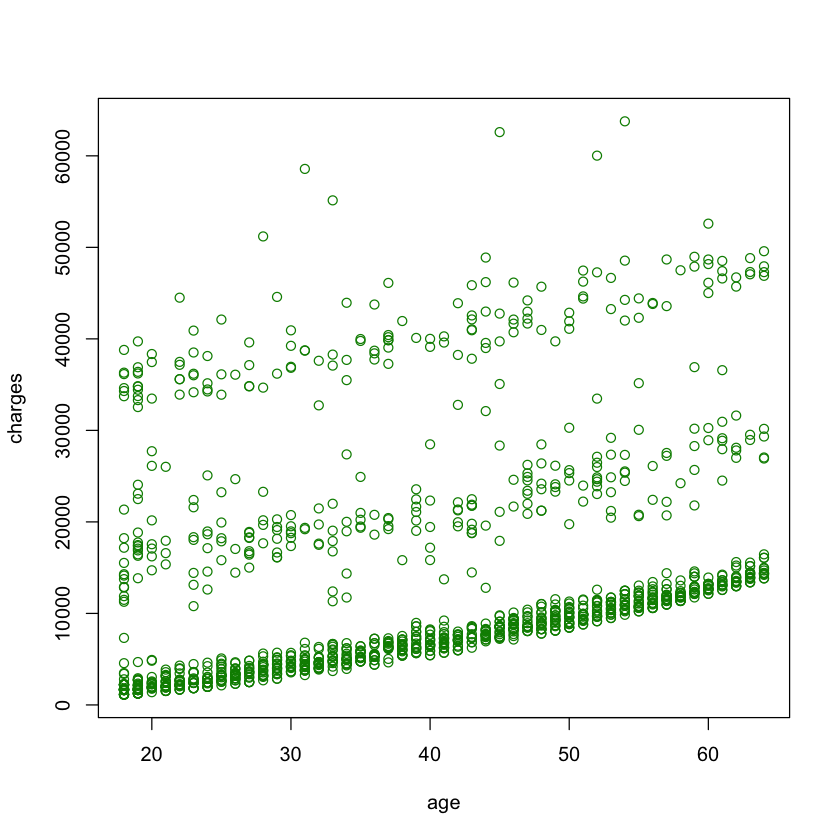

```r
plot(data = d, charges ~ age, col = "green4")
```

When finding correlation between age and expense, plot chart shows something that isn't quite clear. To see a clearer picture, I subset the smoker and nonsmoker:

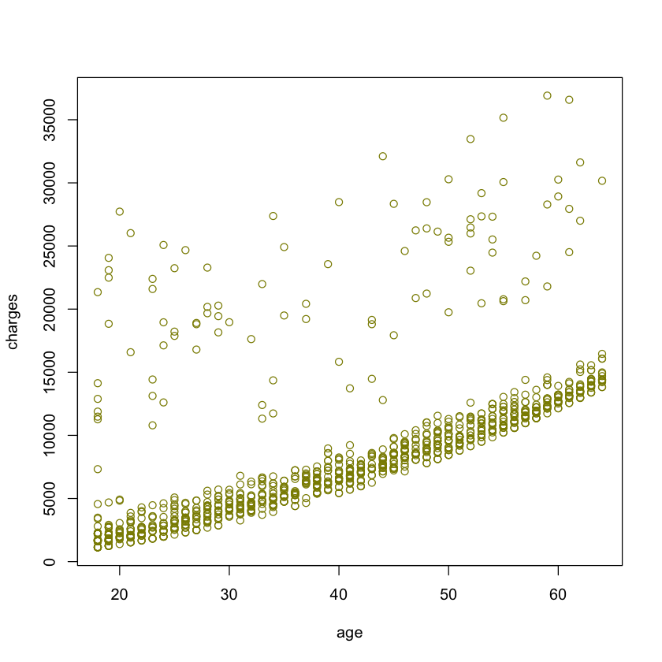

```r
plot(data = d[d$smoker == "no",], charges ~ age, col = "yellow4")
```

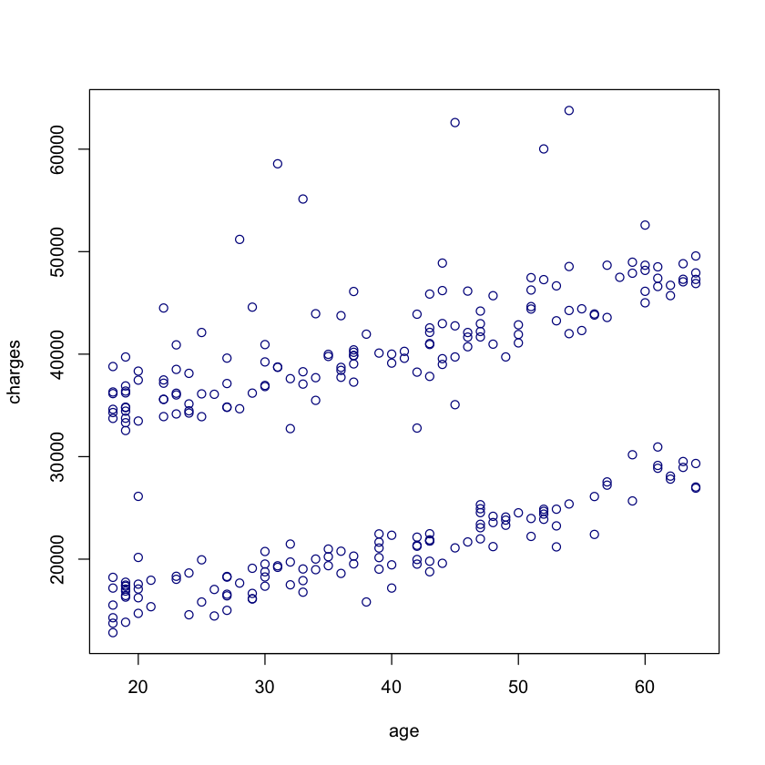

```r
plot(data = d[d$smoker == "yes",], charges ~ age, col = "blue4")
```

- We can see whether smoke or not, there is a correlation between age and medical expenses.
- Smokers have overall higher medical expenses than nonsmokers.
- Maximum of medical expense for nonsmoker is around 35k while smoker's is around 60k.
- The percentage of people has lower medical expense is higher in nonsmoker subset.

```r
library(ggplot2)
```

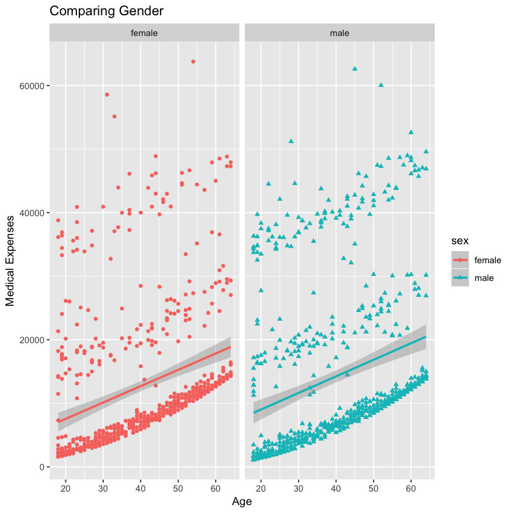

```r
facet <- ggplot(data = d, aes(age, y=charges, color=sex)) +
  geom_point(aes(shape=sex), size=1.5) + geom_smooth(method="lm") +
  xlab("Age") + ylab("Medical Expenses") + ggtitle("Comparing Gender")
facet + facet_grid(. ~ sex)
```

- Age effect male and female on medical spending the same
- slightly higher overall medical expenses of male than female

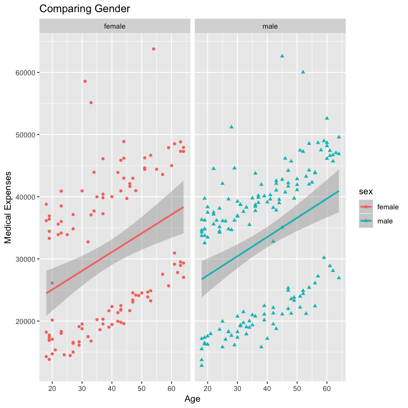

```r
facet <- ggplot(data = d[d$smoker == "yes",], aes(age, y=charges, color=sex)) +
  geom_point(aes(shape=sex), size=1.5) + geom_smooth(method="lm") +
  xlab("Age") + ylab("Medical Expenses") + ggtitle("Comparing Gender")
facet + facet_grid(. ~ sex)
```

- Smoking effect male and female on medical spending the same
- slightly higher overall medical expenses of male than female

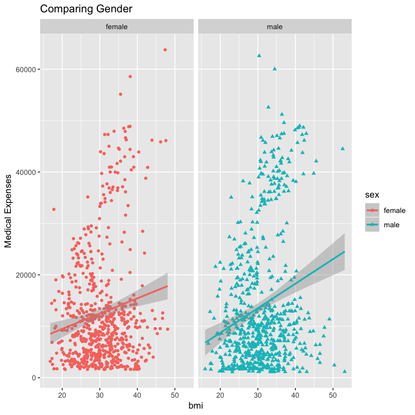

```r
facet <- ggplot(data = d, aes(bmi, y=charges, color=sex)) +
  geom_point(aes(shape=sex), size=1.5) + geom_smooth(method="lm") +
  xlab("bmi") + ylab("Medical Expenses") + ggtitle("Comparing Gender")
facet + facet_grid(. ~ sex)
```

- Males with higher BMI tend to spend more on medical expenses than females.
- That's because males' weight is more than female's even though they share similar height
- So substting into people who is overweighted, which according to Google, is BMI > 30

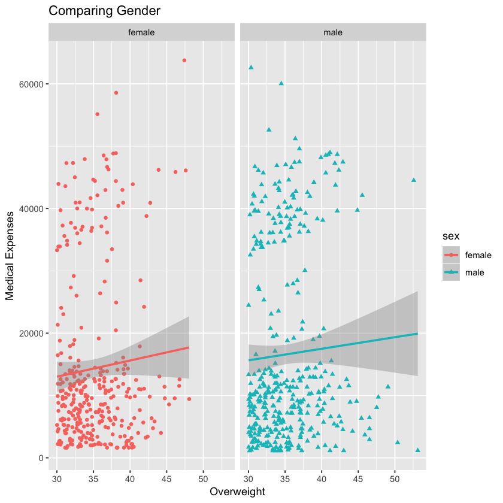

```r
d_overweight <- d[d$bmi > 30,]
facet <- ggplot(data = d_overweight, aes(bmi, y=charges, color=sex)) +
  geom_point(aes(shape=sex), size=1.5) + geom_smooth(method="lm") +
  xlab("Overweight") + ylab("Medical Expenses") + ggtitle("Comparing Gender")
facet + facet_grid(. ~ sex)
```

- This time the slopes look similar again.
- Women has few BMI > 48 is also because males' weight can be more than female's even though they share similar height.

# 9

Select one numerical continuous variable as your response variable and run a linear regression on your data.  
**Response Variable**: Explain your numerical continuous response variable. What does it represent? Why did you select that variable? What are you expecting to find?

### My answer

- Response Variable is the medical expense.
- It represent how much an individual spend annually on his/her medical issues.
- The reason I select it is to see how will it change among people with different life style so that I can suggest insurance company on setting up prices for different groups of people.
- I am expected to find the correlation between smoker with unhealthy BMI and their annual medical charge.

# 10

**Explore Correlations**: Create plots that explain the correlation between your variables, specifically concentrating on your exploratory variable

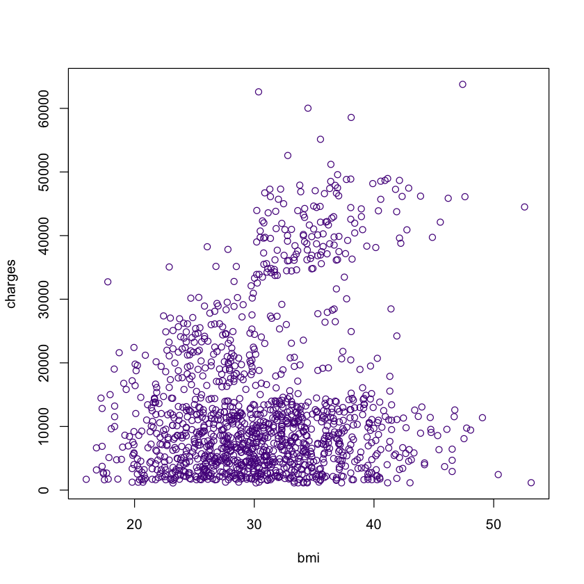

```r
plot(data = d, charges ~ bmi, col = "purple4")
```

Still it doesn't make much sense. Subsetting into smoker and nonsmoker.

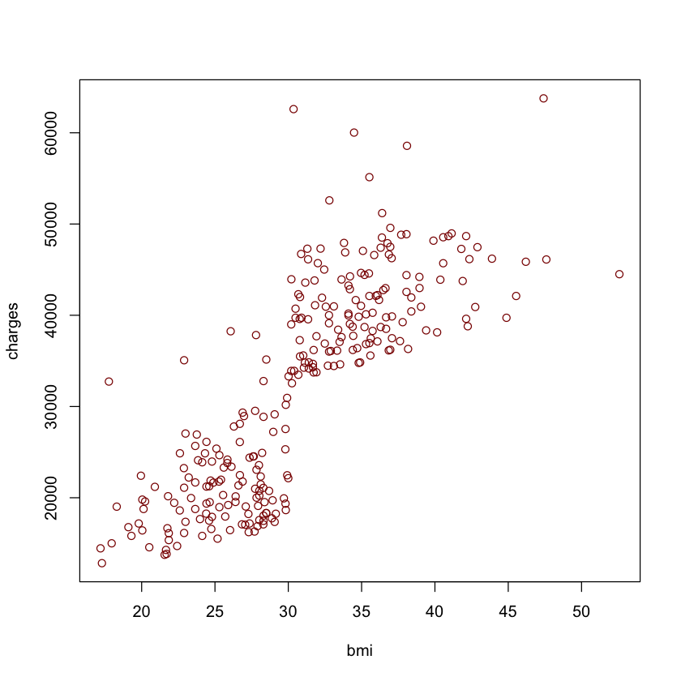

```r
plot(data = d[d$smoker == "yes",], charges ~ bmi, col = "red4")
```

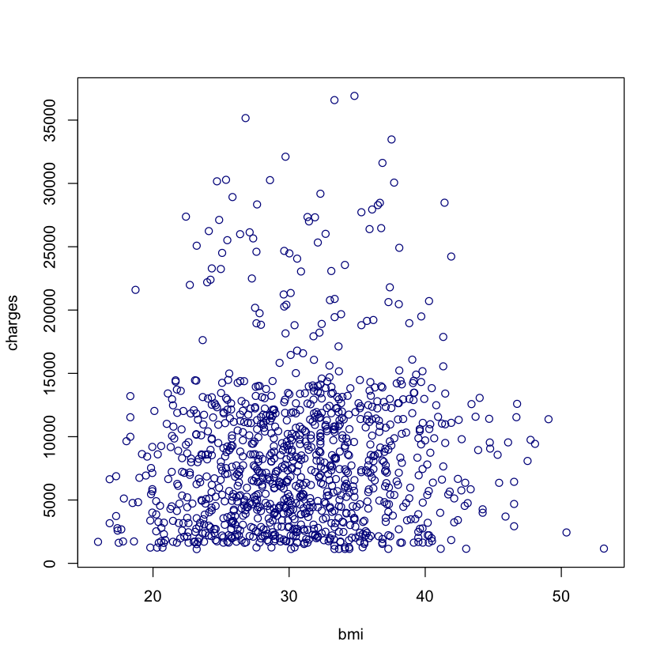

```r
plot(data = d[d$smoker == "no",], charges ~ bmi, col = "blue4")
```

- For smokers, there is a visually correlation of BMI and medical charges. The high the BMI, the more it cost them on medical.
- For nonsmokers, there still isn't much to see from the chart. Guess is because the people in different range of BMI is not evenly distributed or people with too high or too low BMI tend to ignore their health condition explained by not spending much on medical.
- Smoking habbit is the biggest factor in deciding charges.

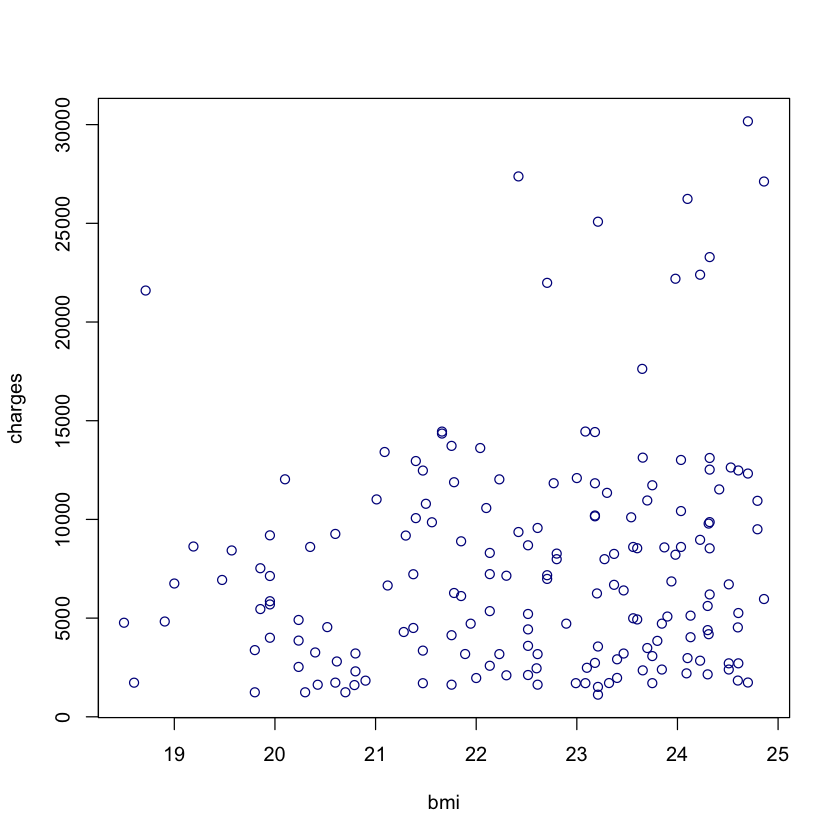

```r
plot(data = d[d$smoker == "no" & d$Normal_BMI == TRUE,], charges ~ bmi, col = "blue4")
```

- If we subsetting again for those who have normal BMI, we can see there is still no clear correlation between charges and bmi.
- But morjority distributed below 15k. My guess is those are basic medical expenses for annual checking or small illness that these group of people would do regularly.

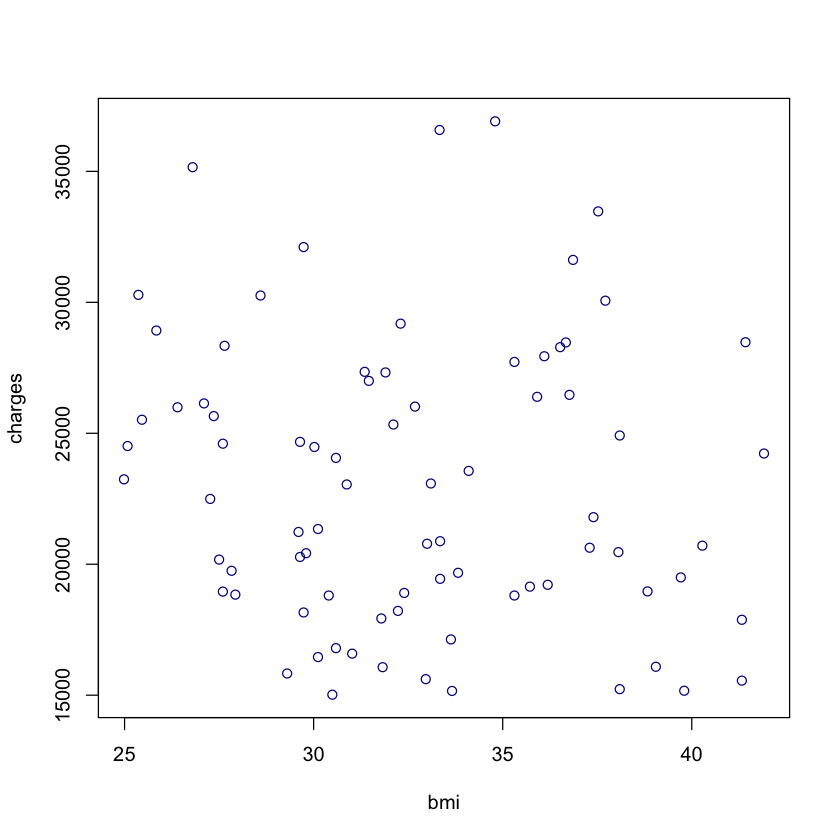

```r
plot(data = d[d$smoker == "no" & d$Normal_BMI == FALSE & d$charge > 15000,], charges ~ bmi, col = "blue4")
```

So far, BMI is useless? But remember Free_Life_Style make correlation with charges increase by 1%? Then it must be the effect under both smoke and unhealthy BMI.

# 11

**Linear Regression**: Run linear regressions that predict your variable. Explain your steps.

```r
# d1 is the subset that only has smokers
d1 <- d[d$smoker == "yes",]
```

```r
X <- as.matrix(cbind(1, d1$bmi))
y <- as.matrix(d1$charges)
bh <- round(solve(t(X) %*% X) %*% t(X) %*% y, 2)
print(bh)
```

```
          [,1]
[1,] -13186.58
[2,]   1473.11
```

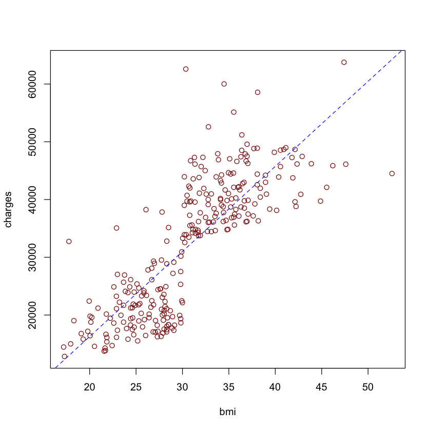

```r
plot(data = d[d$smoker == "yes",], charges ~ bmi, col = "red4")
abline(a = bh[1], b = bh[2], col = "blue", lty="dashed")
```

```r
mod <- lm(d1$charges ~ d1$bmi)
summary(mod)
```

```
Call:
lm(formula = d1$charges ~ d1$bmi)

Residuals:
     Min       1Q   Median       3Q      Max
-19768.0  -4487.9     34.4   3263.9  31055.9

Coefficients:
             Estimate Std. Error t value Pr(>|t|)
(Intercept) -13186.58    2052.88  -6.423 5.93e-10 ***
d1$bmi        1473.11      65.48  22.496  < 2e-16 ***
---
Signif. codes:  0 ‘***’ 0.001 ‘**’ 0.01 ‘*’ 0.05 ‘.’ 0.1 ‘ ’ 1

Residual standard error: 6837 on 272 degrees of freedom
Multiple R-squared:  0.6504,	Adjusted R-squared:  0.6491
F-statistic: 506.1 on 1 and 272 DF,  p-value: < 2.2e-16
```

```r
mod_all <- lm(data = d, charges ~.)
summary(mod_all)
```

```
Call:
lm(formula = charges ~ ., data = d)

Residuals:
     Min       1Q   Median       3Q      Max
-14035.0  -2249.3   -905.1    620.3  27823.3

Coefficients:
                     Estimate Std. Error t value Pr(>|t|)
(Intercept)         -11968.96    1142.73 -10.474  < 2e-16 ***
age                    262.81      11.05  23.786  < 2e-16 ***
sexmale               -369.80     308.88  -1.197 0.231433
bmi                    324.27      32.70   9.917  < 2e-16 ***
children1              256.91     390.69   0.658 0.510923
children2             1575.21     432.66   3.641 0.000282 ***
children3             1044.06     508.12   2.055 0.040101 *
children4             2989.85    1149.36   2.601 0.009390 **
children5              615.66    1350.29   0.456 0.648502
smokeryes            11671.93     906.41  12.877  < 2e-16 ***
regionnorthwest       -581.97     442.14  -1.316 0.188318
regionsoutheast      -1038.53     444.55  -2.336 0.019631 *
regionsouthwest      -1222.31     443.63  -2.755 0.005945 **
Normal_BMITRUE        3011.69     559.82   5.380 8.81e-08 ***
Free_Life_StyleTRUE  14803.52     998.95  14.819  < 2e-16 ***
---
Signif. codes:  0 ‘***’ 0.001 ‘**’ 0.01 ‘*’ 0.05 ‘.’ 0.1 ‘ ’ 1

Residual standard error: 5615 on 1323 degrees of freedom
Multiple R-squared:  0.7873,	Adjusted R-squared:  0.785
F-statistic: 349.7 on 14 and 1323 DF,  p-value: < 2.2e-16
```

```r
d_original <- d[, -c(8, 9)]
mod_original <- lm(data = d_original, charges ~.)
summary(mod_original)
```

```
Call:
lm(formula = charges ~ ., data = d_original)

Residuals:
     Min       1Q   Median       3Q      Max
-11689.4  -2902.6   -943.7   1492.2  30042.7

Coefficients:
                 Estimate Std. Error t value Pr(>|t|)
(Intercept)     -11927.17     993.66 -12.003  < 2e-16 ***
age                257.19      11.91  21.587  < 2e-16 ***
sexmale           -128.16     332.83  -0.385 0.700254
bmi                336.91      28.61  11.775  < 2e-16 ***
children1          390.98     421.35   0.928 0.353619
children2         1635.78     466.67   3.505 0.000471 ***
children3          964.34     548.10   1.759 0.078735 .
children4         2947.37    1239.16   2.379 0.017524 *
children5         1116.04    1456.02   0.767 0.443514
smokeryes        23836.41     414.14  57.557  < 2e-16 ***
regionnorthwest   -380.04     476.56  -0.797 0.425318
regionsoutheast  -1033.14     479.14  -2.156 0.031245 *
regionsouthwest   -952.89     478.15  -1.993 0.046483 *
---
Signif. codes:  0 ‘***’ 0.001 ‘**’ 0.01 ‘*’ 0.05 ‘.’ 0.1 ‘ ’ 1

Residual standard error: 6059 on 1325 degrees of freedom
Multiple R-squared:  0.7519,	Adjusted R-squared:  0.7497
F-statistic: 334.7 on 12 and 1325 DF,  p-value: < 2.2e-16
```

The R Square improved by 3% using new model

# 12

**Project Summary**: Write a few sentences about the result of this project. How can your stakeholder benefit from the results of your project? Which changes or adaptations can your stakehoders make now that he has your results?

# 13

**Project Report**: Write a formal report to your stakeholders with the summary of your report

[output not shown]